# My first kernel for the Titanic sinking competition

Stefano Galeano

4 April 2018

# Kaggle Introduction

The sinking of the RMS Titanic is one of the most infamous shipwrecks in history. On April 15, 1912, during her maiden voyage, the Titanic sank after colliding with an iceberg, killing 1502 out of 2224 passengers and crew. This sensational tragedy shocked the international community and led to better safety regulations for ships.

One of the reasons that the shipwreck led to such loss of life was that there were not enough lifeboats for the passengers and crew. Although there was some element of luck involved in surviving the sinking, some groups of people were more likely to survive than others, such as women, children, and the upper-class.

In this challenge, we ask you to complete the analysis of what sorts of people were likely to survive. In particular, we ask you to apply the tools of machine learning to predict which passengers survived the tragedy.

## Data Dictionary

| Variable | Definition | Key |
| --- | --- | --- |
| survival | Survival | 0 = No, 1 = Yes |
| pclass | Ticket class | 1 = 1st, 2 = 2nd, 3 = 3rd |
| sex | Sex |  |
| Age | Age in years |  |
| sibsp | # of siblings/spouses aboard the Titanic |  |
| ticket | Ticket number |  |
| fare | Passenger fare |  |
| cabin | Cabin number |  |
| embarked | Port of Embarkation | C = Cherbourg, Q = Queenstown, S = Southampton |

### Variable Notes

**pclass**: A proxy for socio-economic status (SES) 1st = Upper 2nd = Middle 3rd = Lower

**age**: Age is fractional if less than 1. If the age is estimated, is it in the form of xx.5

**sibsp**: The dataset defines family relations in this way… Sibling = brother, sister, stepbrother, stepsister Spouse = husband, wife (mistresses and fiancés were ignored)

**parch**: The dataset defines family relations in this way… Parent = mother, father Child = daughter, son, stepdaughter, stepson Some children travelled only with a nanny, therefore parch=0 for them.

# Executive summary

This is my first kernel and bellow the main points that characterize my work:

- use less predictors as possible in order to promote interpretability
- compare different ML algorihtm and combine them in order to increase power prediction

# Getting data

## Library import

```r
library(kableExtra)
library(ggplot2) # Visualization
library(tibble)
library(tidyr)
library(dplyr) # Data manipulation
library(corrplot) # Correlattion plot
library(pROC) # Roc curve
library(caret)
library(party)
library(HDoutliers)
```

## Importing and cleaning Data

```r
# Importing train/test dataset in R
train <- read.csv('../input/train.csv', header = TRUE, stringsAsFactors = FALSE, na.strings = c(""))
train$Set = "train"
test <- read.csv('../input/test.csv', header = TRUE,stringsAsFactors = FALSE, na.strings = c(""))
test$Set = "test"

# In order to streamline the cleaning process, the train and test datasets are binded. A dummy column is added in order to keep track of the original data source
test$Survived <- NA
full <- rbind(train,test)
```

```r
# Coercing features from char to factor
full$Sex <- as.factor(full$Sex)
full$Embarked <- as.factor(full$Embarked)
full$Pclass <- as.factor(full$Pclass)
# The levels if the Survived feature (outcome) are temporarly changed. The orginal ones are kept in a variable
full$Survived <- as.factor(full$Survived); origLevels <- levels(full$Survived); levels(full$Survived) <- c("dead","survived")
```

## Survival distribution

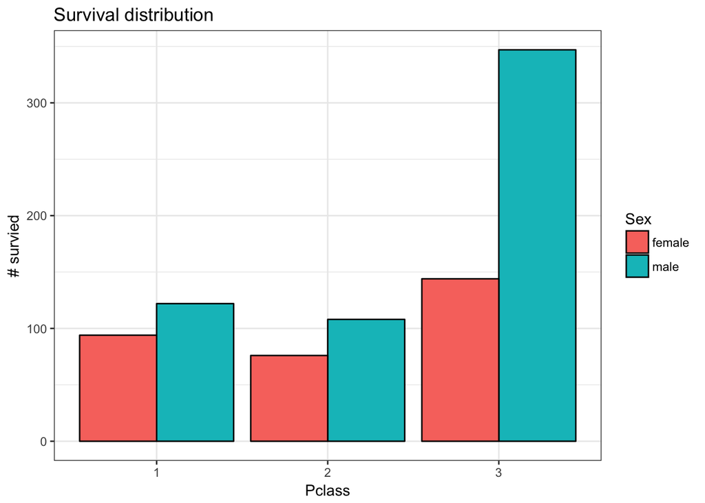

```r
g <- ggplot(filter(full,!is.na(Survived)),aes(Survived))
g <- g + geom_bar(colour = "black", aes(fill=Sex, Pclass),position="dodge")
g <- g + labs(title = "Survival distribution", x = "Pclass", y = "# survied") + theme_bw()
g
```

## Missing value analysis:

Let’s first have a look at the percentage of missing value for each feature:

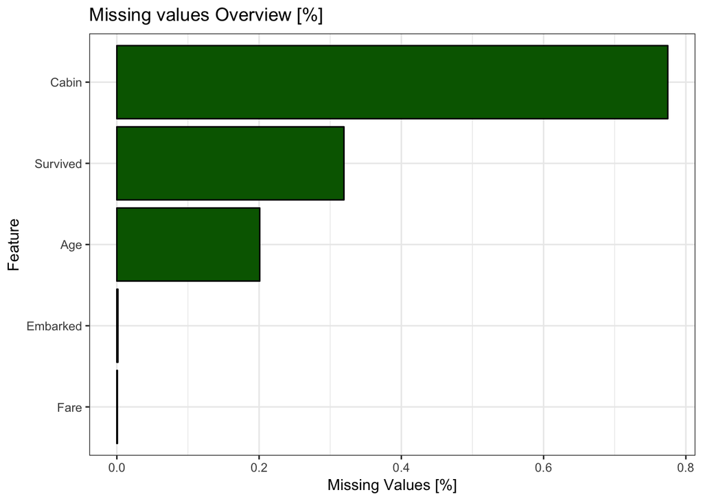

```r
missingValue <- sapply(full, function(feature){
    sum(is.na(feature))/length(feature)
})
missingValue <- data.frame(feature = names(missingValue), percentage = missingValue) %>% filter(percentage != 0)

g <- ggplot(missingValue,
            aes(reorder(feature, percentage),percentage))
g <- g + geom_bar(stat = "identity", fill="dark green", color="black")
g <- g + labs(title = "Missing values Overview [%]", x = "Feature", y = "Missing Values [%]")
g <- g + coord_flip() + theme_bw()
g
```

The cabin feature has almost 80% of NA values. Maybe the NA’s here have the meaning of: no cabin.

## Cleaning data

### Name: extracting Title and Family Name

A bunch of entries from the `Name` feature:

```r
head(full$Name)
```

```
## [1] "Braund, Mr. Owen Harris"
## [2] "Cumings, Mrs. John Bradley (Florence Briggs Thayer)"
## [3] "Heikkinen, Miss. Laina"
## [4] "Futrelle, Mrs. Jacques Heath (Lily May Peel)"
## [5] "Allen, Mr. William Henry"
## [6] "Moran, Mr. James"
```

Each `Name` is of the form `String, Title. String`, where the first one is the family name.

The idea behind this extraction is not to use them for training the model, but to use them in order to: + understand the family status (married or maiden) + wheater or not is part of the crew + handle NA’s for the `Age`

Regular expressions are used in order to extract the `Name.family` and `Name.title`

```r
full$Name.family <- gsub(pattern = "([\\w|\\-| |']*), ([\\w| ]*\\.) (.*)", x=full$Name, replacement="\\1", ignore.case=TRUE, perl = TRUE)
full$Name.title <- gsub(pattern = "([\\w|\\-| |']*), ([\\w| ]*\\.) (.*)", x=full$Name, replacement="\\2", ignore.case=TRUE, perl = TRUE)
```

#### Feature engineering: family name count:

```r
Name.family <- full %>% group_by(Name.family) %>% summarise(Name.family.count = n())
full <- inner_join(full,Name.family, by = "Name.family")
```

```r
knitr::kable(table(full$Name.title),"html") %>%
    kable_styling() %>%
    scroll_box(height = "200px")
```

| Var1 | Freq |
| --- | --- |
| Capt. | 1 |
| Col. | 4 |
| Don. | 1 |
| Dona. | 1 |
| Dr. | 8 |
| Jonkheer. | 1 |
| Lady. | 1 |
| Major. | 2 |
| Master. | 61 |
| Miss. | 260 |
| Mlle. | 2 |
| Mme. | 1 |
| Mr. | 757 |
| Mrs. | 197 |
| Ms. | 2 |
| Rev. | 8 |
| Sir. | 1 |
| the Countess. | 1 |

As we can see from the last output, many titles have only few occurence. The less frequent titles are pooled in the more common ones:

```r
full <- full %>% mutate(
    Title = as.factor(case_when(
        # Young boy less then 18 years old
        Name.title == "Master."                         ~ "Master",

        # Girl or unmarried women
        Name.title == "Miss." |
            Name.title == "Mlle."                   ~ "Miss",

        # Women married
        Name.title == "Mrs."  |
            Name.title == "Mme."  |
            Name.title == "Dona."                   ~ "Mrs",

        # Women with unspecified status
        Name.title == "Ms."           |
            Name.title == "Lady."         |
            Name.title == "the Countess." |
            Name.title == "Dr." & Sex == "female"   ~ "Mrs", # In this group because there are too few observation

        # Men
        Name.title == "Mr."       |
            Name.title == "Sir."      |
            Name.title == "Rev."      |
            Name.title == "Don."      |
            Name.title == "Jonkheer." |
            Name.title == "Dr." & Sex == "male"     ~ "Mr",

        # Crew
        Name.title == "Capt." |
            Name.title == "Col."  |
            Name.title == "Major."                  ~ "Mr" # In this group because it wasn't significative in the final model
    ))
)
```

Below it’s shown the new histogram of the `Title` feature just created:

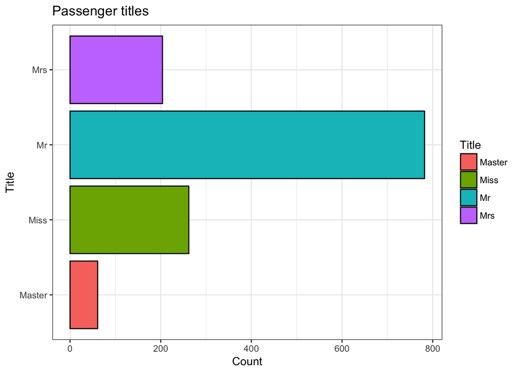

```r
g <- ggplot(full, aes(Title))
g <- g + geom_bar(color="black", aes(fill=Title))
g <- g + coord_flip() + labs(title = "Passenger titles", x = "Title", y = "Count") + theme_bw()
g
```

### Ticket: Ticket number

Using the same approch used for the Title (checking the structure of the entries and using regex), the `Ticket.number` is extracted:

```r
full$Ticket.number <- gsub(pattern = "^((.*) )?(\\d*)?$", x=full$Ticket, replacement="\\3")
# Since we want to treat them as number the tickets which start with LINE are replaced with the 0
full$Ticket.number <- gsub(pattern = "^LINE$", x=full$Ticket.number, replacement="0")
full$Ticket.number <- as.integer(full$Ticket.number)
```

## Cabin: extracting the deck

```r
full <- full %>% mutate(Cabin.Deck = as.factor(case_when(
    grepl("^A",Cabin) ~ "A",
    grepl("^B",Cabin) ~ "B",
    grepl("^C",Cabin) ~ "C",
    grepl("^D",Cabin) ~ "D",
    grepl("^E",Cabin) ~ "E",
    grepl("^F",Cabin) ~ "F",
    grepl("^G",Cabin) ~ "G",
    grepl("^T",Cabin) ~ "T",
    TRUE ~ "NONE"
)))
```

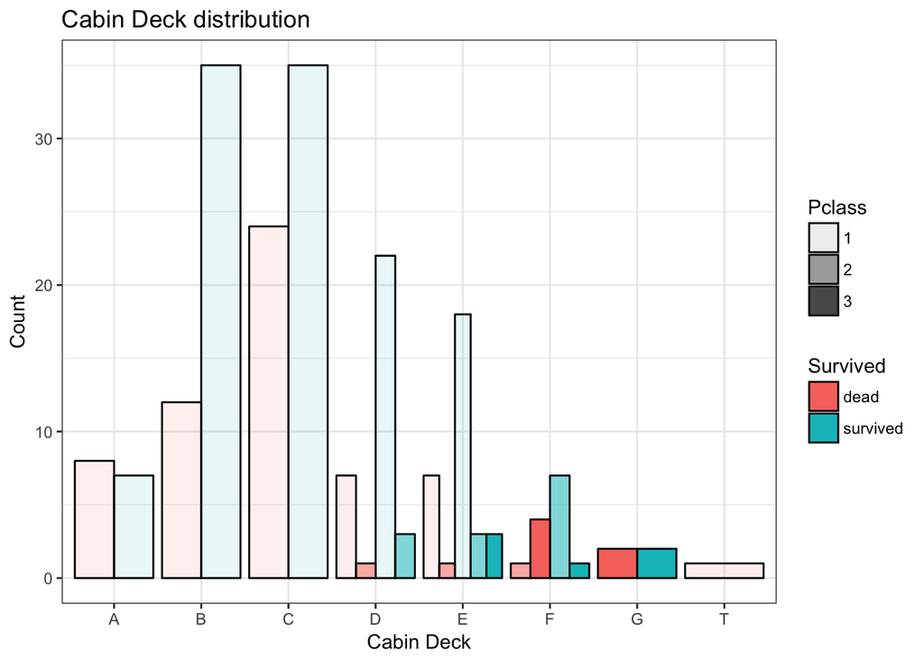

```r
g <- ggplot(filter(full,Cabin.Deck != "NONE" & Set=="train"), aes(Cabin.Deck))
g <- g + geom_bar(color="black", aes(fill=Survived, alpha=Pclass), position = "dodge")
g <- g + labs(title = "Cabin Deck distribution", x = "Cabin Deck", y = "Count") + theme_bw()
g
```

## Missing Value imputation

### Age

Two different imputation techniques are tried:

- fit a tree-based model using `Age` and `Title`;
- replacing with the median age inside inside the Title group of appartenance.

### Tree based

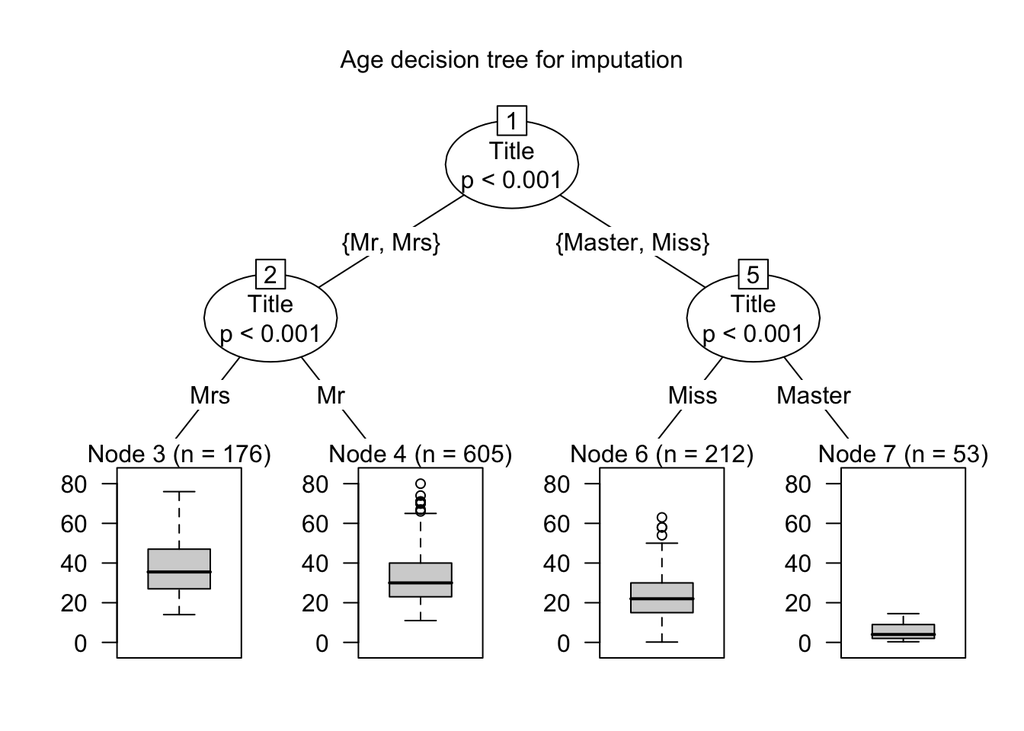

```r
df <- full %>% select(Age,Title) %>% filter(!is.na(Age))

fit <- ctree(Age~., data=df)
plot(fit, main="Age decision tree for imputation")
```

```r
full$Age.ctree <- as.vector(predict(fit,full))
full <- full %>% mutate(Age.imputed=ifelse(is.na(Age),Age.ctree,Age))
```

### Median inside the Title group

By looking at the `Age` distribution for each `Title`:

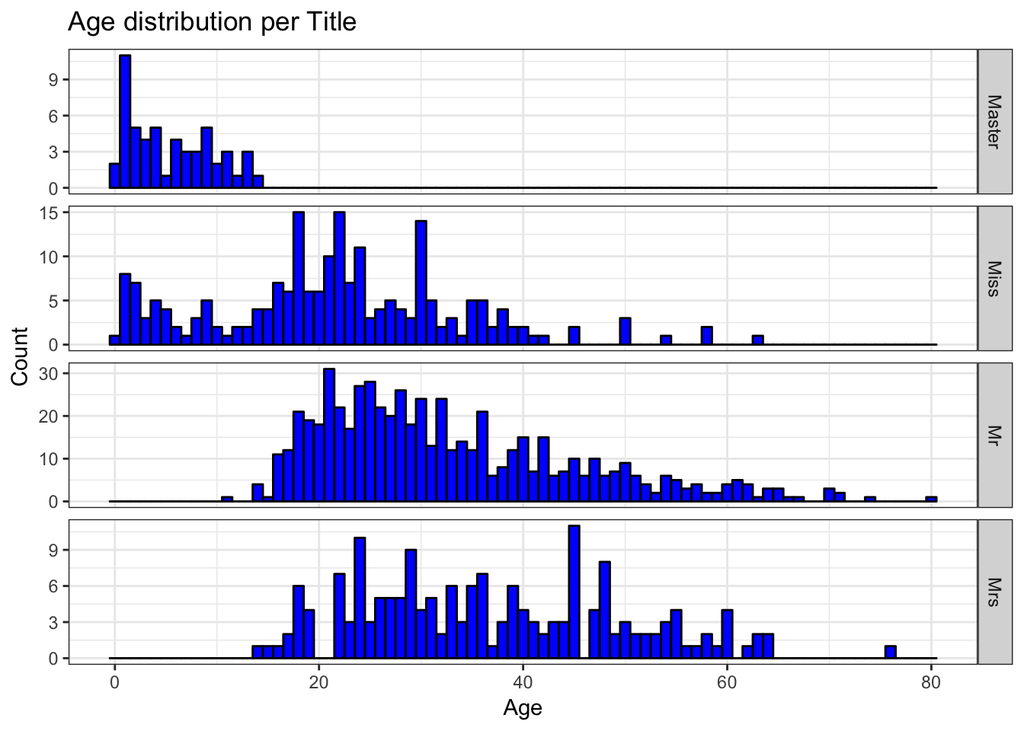

```r
g <- ggplot(data = filter(full,!is.na(Age)), aes(Age))
g <- g + geom_histogram(binwidth = 1, fill="blue", color="black")
g <- g + labs(title = "Age distribution per Title", x = "Age", y = "Count") + theme_bw()
g + facet_grid(Title~., scales = "free")
```

it seems reasonable to use the median `Age` in the `Title` group of appartenency.

```r
full <- full %>% group_by(Title) %>% mutate(Age.median = median(Age,na.rm = TRUE)) %>% ungroup(Title)
full <- full %>% mutate(Age = if_else(is.na(Age),Age.median,Age))
```

### Embarked

In order to impute the Embarked feature we get help from the `Ticket.number` distribution in each `Embarked` group:

```r
knitr::kable(full %>% filter(is.na(Embarked)),"html") %>%
    kable_styling() %>%
    scroll_box(height = "220px")
```

| PassengerId | Survived | Pclass | Name | Sex | Age | SibSp | Parch | Ticket | Fare | Cabin | Embarked | Set | Name.family | Name.title | Name.family.count | Title | Ticket.number | Cabin.Deck | Age.ctree | Age.imputed | Age.median |
| --- | --- | --- | --- | --- | --- | --- | --- | --- | --- | --- | --- | --- | --- | --- | --- | --- | --- | --- | --- | --- | --- |
| 62 | survived | 1 | Icard, Miss. Amelie | female | 38 | 0 | 0 | 113572 | 80 | B28 | NA | train | Icard | Miss. | 1 | Miss | 113572 | B | 21.79524 | 38 | 22.0 |
| 830 | survived | 1 | Stone, Mrs. George Nelson (Martha Evelyn) | female | 62 | 0 | 0 | 113572 | 80 | B28 | NA | train | Stone | Mrs. | 1 | Mrs | 113572 | B | 36.98864 | 62 | 35.5 |

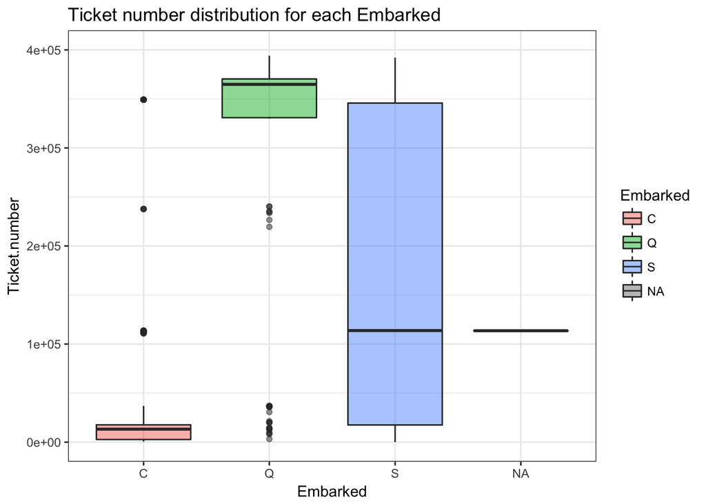

```r
g <- ggplot(data = full, aes(Embarked,Ticket.number))
g <- g + geom_boxplot(aes(fill = Embarked), alpha = 0.5) + ylim(0, 400000)
g <- g + theme_bw() + labs(title = "Ticket number distribution for each Embarked", x = "Embarked", y = "Ticket.number")
g
```

Since we only have few missing NA, we decided to use a naive approch: replacing NA’s with S.

```r
full$Embarked <- as.factor(if_else(is.na(full$Embarked),"S",as.character(full$Embarked)))
```

### Cabin

Since the high number of missing values for the `Cabin` the feature is removed. A `hasCabin` feature is created:

```r
full <- full %>% mutate(
    HasCabin = if_else(is.na(Cabin), FALSE, TRUE)
)
full$Cabin <- NULL
```

### Fare

```r
full %>% filter(is.na(Fare))
```

```
## # A tibble: 1 x 22
##   PassengerId Survived Pclass Name    Sex     Age SibSp Parch Ticket  Fare
##         <int> <fct>    <fct>  <chr>   <fct> <dbl> <int> <int> <chr>  <dbl>
## 1        1044 <NA>     3      Storey… male   60.5     0     0 3701      NA
## # ... with 12 more variables: Embarked <fct>, Set <chr>,
## #   Name.family <chr>, Name.title <chr>, Name.family.count <int>,
## #   Title <fct>, Ticket.number <int>, Cabin.Deck <fct>, Age.ctree <dbl>,
## #   Age.imputed <dbl>, Age.median <dbl>, HasCabin <lgl>
```

Here again, since we only have one missing value, the mean among similar profiles is used for the imputation:

```r
knitr::kable(
    full %>%
        filter(!is.na(Fare),SibSp+Parch==0,HasCabin==FALSE,Sex=="male",Name.family.count==1,Embarked=="S",between(Age,50,70)),
    "html") %>%
    kable_styling() %>%
    scroll_box(height = "200px")
```

| PassengerId | Survived | Pclass | Name | Sex | Age | SibSp | Parch | Ticket | Fare | Embarked | Set | Name.family | Name.title | Name.family.count | Title | Ticket.number | Cabin.Deck | Age.ctree | Age.imputed | Age.median | HasCabin |
| --- | --- | --- | --- | --- | --- | --- | --- | --- | --- | --- | --- | --- | --- | --- | --- | --- | --- | --- | --- | --- | --- |
| 34 | dead | 2 | Wheadon, Mr. Edward H | male | 66.0 | 0 | 0 | C.A. 24579 | 10.5000 | S | train | Wheadon | Mr. | 1 | Mr | 24579 | NONE | 32.7843 | 66.0 | 30 | FALSE |
| 95 | dead | 3 | Coxon, Mr. Daniel | male | 59.0 | 0 | 0 | 364500 | 7.2500 | S | train | Coxon | Mr. | 1 | Mr | 364500 | NONE | 32.7843 | 59.0 | 30 | FALSE |
| 151 | dead | 2 | Bateman, Rev. Robert James | male | 51.0 | 0 | 0 | S.O.P. 1166 | 12.5250 | S | train | Bateman | Rev. | 1 | Mr | 1166 | NONE | 32.7843 | 51.0 | 30 | FALSE |
| 153 | dead | 3 | Meo, Mr. Alfonzo | male | 55.5 | 0 | 0 | A.5. 11206 | 8.0500 | S | train | Meo | Mr. | 1 | Mr | 11206 | NONE | 32.7843 | 55.5 | 30 | FALSE |
| 223 | dead | 3 | Green, Mr. George Henry | male | 51.0 | 0 | 0 | 21440 | 8.0500 | S | train | Green | Mr. | 1 | Mr | 21440 | NONE | 32.7843 | 51.0 | 30 | FALSE |
| 233 | dead | 2 | Sjostedt, Mr. Ernst Adolf | male | 59.0 | 0 | 0 | 237442 | 13.5000 | S | train | Sjostedt | Mr. | 1 | Mr | 237442 | NONE | 32.7843 | 59.0 | 30 | FALSE |
| 318 | dead | 2 | Moraweck, Dr. Ernest | male | 54.0 | 0 | 0 | 29011 | 14.0000 | S | train | Moraweck | Dr. | 1 | Mr | 29011 | NONE | 32.7843 | 54.0 | 30 | FALSE |
| 327 | dead | 3 | Nysveen, Mr. Johan Hansen | male | 61.0 | 0 | 0 | 345364 | 6.2375 | S | train | Nysveen | Mr. | 1 | Mr | 345364 | NONE | 32.7843 | 61.0 | 30 | FALSE |
| 407 | dead | 3 | Widegren, Mr. Carl/Charles Peter | male | 51.0 | 0 | 0 | 347064 | 7.7500 | S | train | Widegren | Mr. | 1 | Mr | 347064 | NONE | 32.7843 | 51.0 | 30 | FALSE |
| 468 | dead | 1 | Smart, Mr. John Montgomery | male | 56.0 | 0 | 0 | 113792 | 26.5500 | S | train | Smart | Mr. | 1 | Mr | 113792 | NONE | 32.7843 | 56.0 | 30 | FALSE |
| 483 | dead | 3 | Rouse, Mr. Richard Henry | male | 50.0 | 0 | 0 | A/5 3594 | 8.0500 | S | train | Rouse | Mr. | 1 | Mr | 3594 | NONE | 32.7843 | 50.0 | 30 | FALSE |
| 546 | dead | 1 | Nicholson, Mr. Arthur Ernest | male | 64.0 | 0 | 0 | 693 | 26.0000 | S | train | Nicholson | Mr. | 1 | Mr | 693 | NONE | 32.7843 | 64.0 | 30 | FALSE |
| 583 | dead | 2 | Downton, Mr. William James | male | 54.0 | 0 | 0 | 28403 | 26.0000 | S | train | Downton | Mr. | 1 | Mr | 28403 | NONE | 32.7843 | 54.0 | 30 | FALSE |
| 632 | dead | 3 | Lundahl, Mr. Johan Svensson | male | 51.0 | 0 | 0 | 347743 | 7.0542 | S | train | Lundahl | Mr. | 1 | Mr | 347743 | NONE | 32.7843 | 51.0 | 30 | FALSE |
| 673 | dead | 2 | Mitchell, Mr. Henry Michael | male | 70.0 | 0 | 0 | C.A. 24580 | 10.5000 | S | train | Mitchell | Mr. | 1 | Mr | 24580 | NONE | 32.7843 | 70.0 | 30 | FALSE |
| 695 | dead | 1 | Weir, Col. John | male | 60.0 | 0 | 0 | 113800 | 26.5500 | S | train | Weir | Col. | 1 | Mr | 113800 | NONE | 32.7843 | 60.0 | 30 | FALSE |
| 715 | dead | 2 | Greenberg, Mr. Samuel | male | 52.0 | 0 | 0 | 250647 | 13.0000 | S | train | Greenberg | Mr. | 1 | Mr | 250647 | NONE | 32.7843 | 52.0 | 30 | FALSE |
| 724 | dead | 2 | Hodges, Mr. Henry Price | male | 50.0 | 0 | 0 | 250643 | 13.0000 | S | train | Hodges | Mr. | 1 | Mr | 250643 | NONE | 32.7843 | 50.0 | 30 | FALSE |
| 1279 | NA | 2 | Ashby, Mr. John | male | 57.0 | 0 | 0 | 244346 | 13.0000 | S | test | Ashby | Mr. | 1 | Mr | 244346 | NONE | 32.7843 | 57.0 | 30 | FALSE |

```r
Fare.mean <- as.numeric(full %>% filter(!is.na(Fare),SibSp+Parch==0,HasCabin==FALSE,Sex=="male",Name.family.count==1,Embarked=="S",between(Age,50,70)) %>% summarise(mean(Fare)))
```

Fare mean among the similar profiles:

```r
Fare.mean
```

```
## [1] 13.55614
```

```r
full <- full %>% mutate(Fare=ifelse(is.na(Fare),Fare.mean,Fare))
```

## Data fix

### ParCh and SibSp

As discussde here https://www.kaggle.com/c/titanic/discussion/39787, some well-known biases are fixed.

```r
full$SibSp[full$PassengerId==280] <- 0
full$Parch[full$PassengerId==280] <- 2
full$SibSp[full$PassengerId==1284] <- 1
full$Parch[full$PassengerId==1284] <- 1
```

### Outliers

```r
data <- full %>% select(Age,Title,SibSp,Parch,Pclass,Sex,-Survived) # filter(!is.na(Survived)) %>%
possibleOutliers <- HDoutliers(data)

full <- full %>% mutate(possibleOutlier=if_else(1:nrow(full)==possibleOutliers,TRUE,FALSE))
```

# Feature engineering

## Family and group size: solo or teamwork?

- Does the big families/groups have more chance to survive than the lonesome travelers?

The `Relatives` feature is generated by summing up the `sibsp` (# of siblings/spouses aboard) and the `parch` (# of parent/children aboard):

```r
full$Relatives <- full$Parch + full$SibSp
```

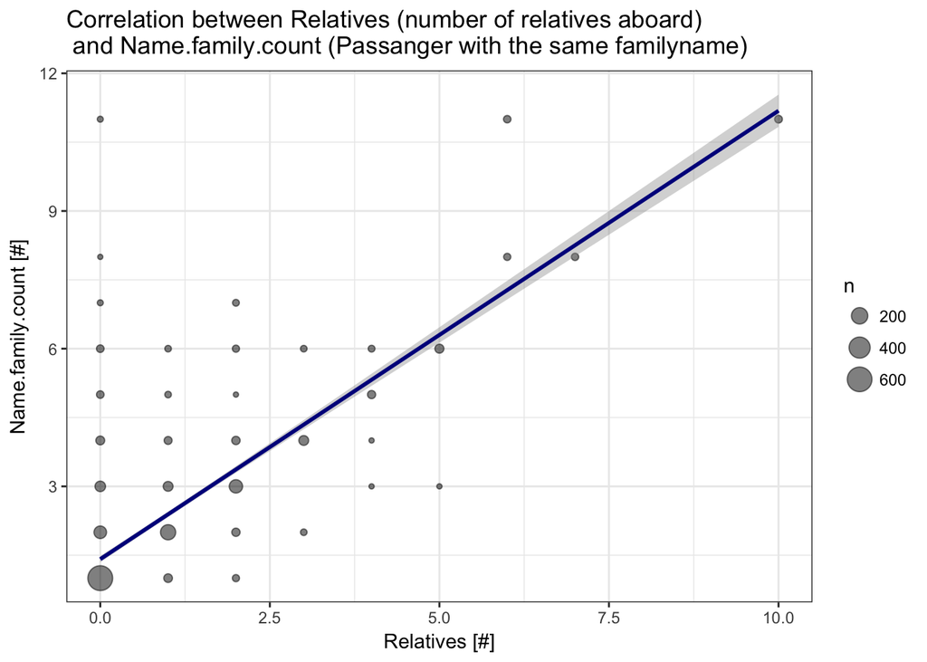

```r
g <- ggplot(data = full, aes(Relatives, Name.family.count))
g <- g + geom_count(fill = "brown", alpha=0.5)
g <- g + geom_smooth(method = "lm", color="dark blue")
g <- g + theme_bw() + labs(title = "Correlation between Relatives (number of relatives aboard)\n and Name.family.count (Passanger with the same familyname)", x = "Relatives [#]", y = "Name.family.count [#]")
g
```

By counting the `Ticket.number`, we can create a new feature.

This feature can give us an estimation of the group size for each ticket. In addition to include some relatives already took into account by the `Relatives` just created, it will also include some friends who were traveling togheter:

```r
ticket <- full %>% group_by(Ticket.number) %>% summarise(Ticket.number.count=n()) %>% mutate(Ticket.number.count=as.integer(Ticket.number.count)) %>% ungroup()
full <- inner_join(full,ticket,by = "Ticket.number")
```

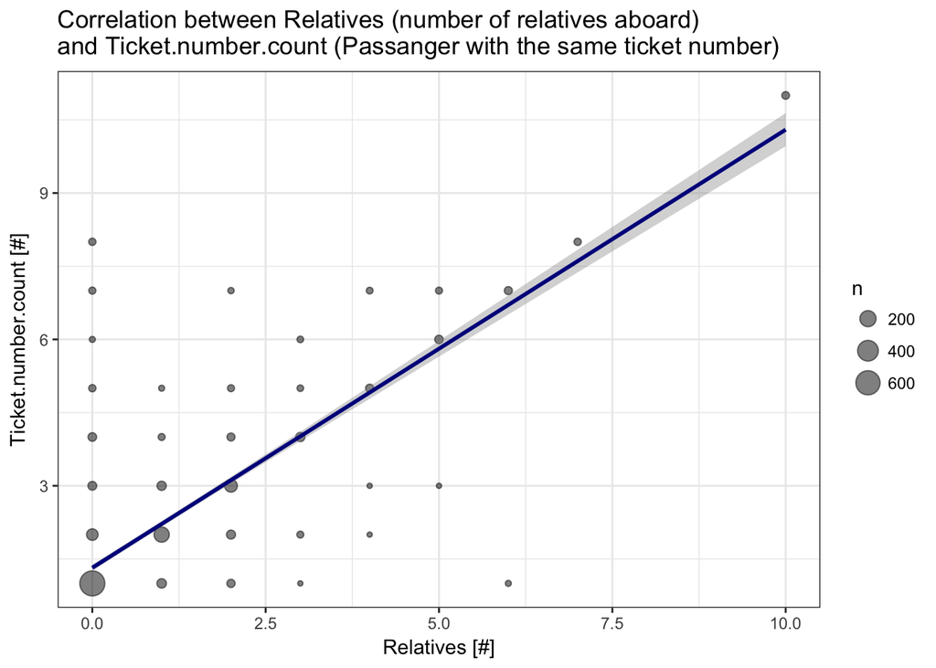

```r
g <- ggplot(data = full, aes(Relatives, Ticket.number.count))
g <- g + geom_count(fill = "brown", alpha=0.5)
g <- g + geom_smooth(method = "lm", color="dark blue")
g <- g + theme_bw() + labs(title = "Correlation between Relatives (number of relatives aboard) \nand Ticket.number.count (Passanger with the same ticket number)", x = "Relatives [#]", y = "Ticket.number.count [#]")
g
```

In order to inlude all possible relations among the passengers, a `Group.size` feature is created taking the max value between `Relatives` and `Ticket.number.count`:

```r
full <- full %>% mutate(Group.size = ifelse(Ticket.number.count < Relatives,Relatives,Ticket.number.count))
```

### Number of survivors in the group

```r
Ticket.survived <- full %>% filter(Survived=="survived") %>% group_by(Ticket.number) %>% summarise(Group.survived=n()-1) %>% ungroup()
full <- left_join(full,Ticket.survived,by="Ticket.number") %>% mutate(Group.survived=ifelse(is.na(Group.survived),0,Group.survived))
```

### Number of survivors with the same family name

```r
Family.survived <- full %>% filter(Survived=="survived") %>% group_by(Name.family) %>% summarise(Family.survived=n()-1) %>% ungroup()
full <- left_join(full,Family.survived,by="Name.family") %>% mutate(Family.survived=ifelse(is.na(Family.survived),0,Family.survived))
```

### Number of survivors

```r
full <- full %>% mutate(Survivors = if_else(Family.survived > Group.survived,Family.survived,Group.survived))
```

### Survivor percentage in group

```r
full <- full %>% mutate(Survivors.percentage = Survivors/Group.size)
```

### Any survivors

```r
full <- full %>% mutate(AnySurvivor = if_else(Survivors==0,FALSE,TRUE))
```

## Fare per person

By Dividng the `Fare` per the `Group.size` just created, we can calculate the Fare per person

```r
full <- full %>% mutate(Fare.per.Person = Fare / Group.size)
```

# Exploratory analysis

The full dataset is splitted back in train and test:

```r
train <- full[full$Set == "train",]
test <- full[full$Set == "test",]
train$Set <- NULL
test$Set <- NULL
```

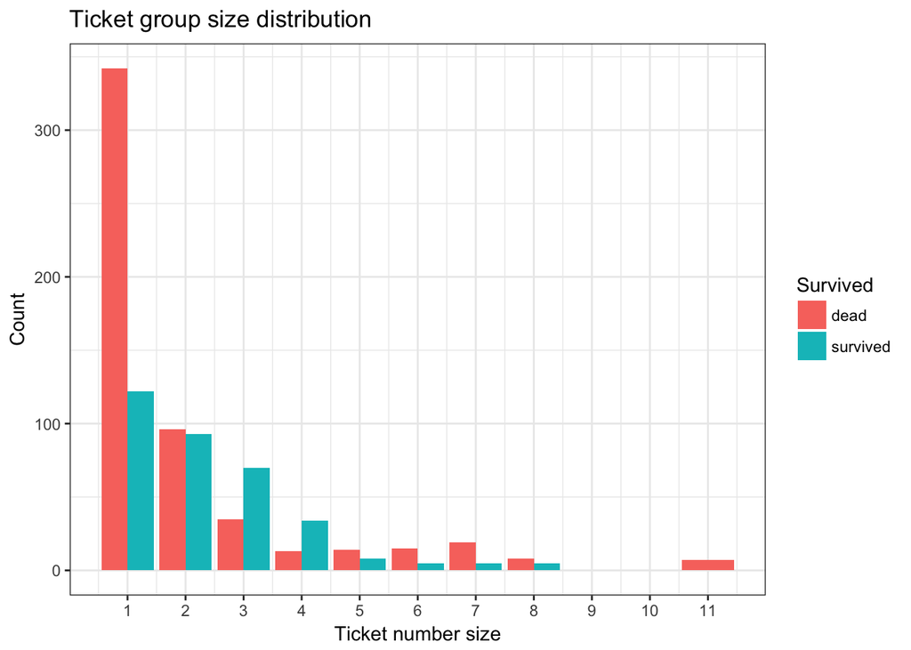

```r
g <- ggplot(data = train, aes(Group.size))
g <- g + geom_bar(position="dodge", aes(fill=Survived))
g <- g + scale_x_continuous(breaks=1:11)
g <- g + labs(title = "Ticket group size distribution", x = "Ticket number size", y = "Count") + theme_bw()
g
```

## Group size bins

```r
full <- full %>% mutate(Group.dim = cut(Group.size, breaks = c(1,2,5,12), labels = c("solo","medium","big"), right = FALSE))
```

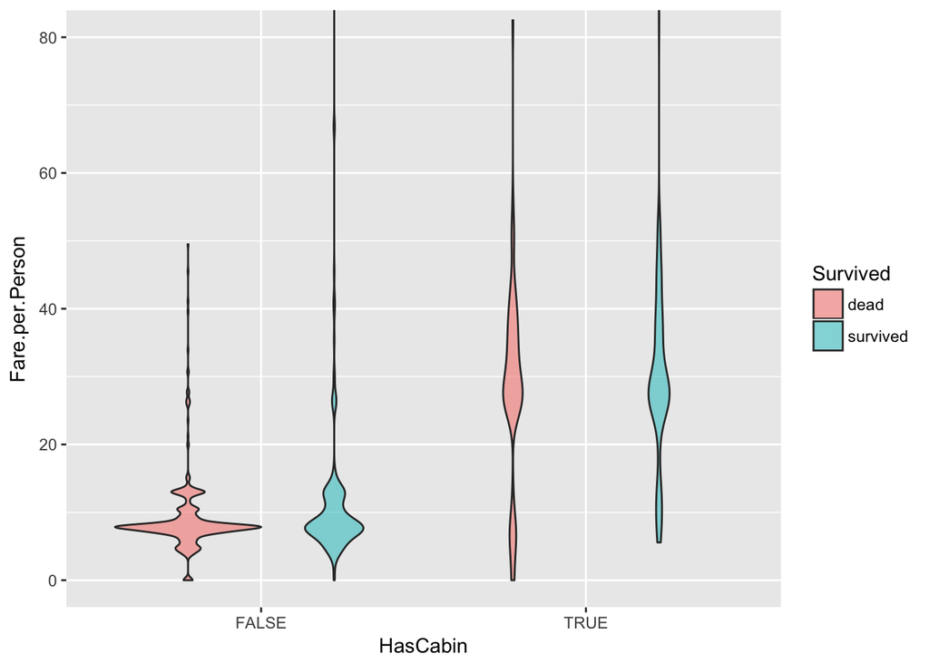

```r
g <- ggplot(train,aes(HasCabin,Fare.per.Person))
g <- g + geom_violin(aes(fill=Survived),alpha=.5,kernel = "gaussian")
g <- g + coord_cartesian(ylim = c(0, 80))
# g <- g + annotate(geom = "text", x = 10, y = .28, label = max(..count..))
g
```

It seems like `Fare.per.Person` below 18 have less chance to survive respect to higher values.

```r
full <- full %>% mutate(Fare.group=as.factor(ifelse(Fare.per.Person>18,"high","low")))
```

```r
full %>% filter(between(Fare.per.Person,20,35),Survived=="dead",HasCabin==TRUE)
```

```
## # A tibble: 35 x 34
##    PassengerId Survived Pclass Name   Sex     Age SibSp Parch Ticket  Fare
##          <int> <fct>    <fct>  <chr>  <fct> <dbl> <dbl> <dbl> <chr>  <dbl>
##  1           7 dead     1      McCar… male    54.    0.    0. 17463   51.9
##  2          55 dead     1      Ostby… male    65.    0.    1. 113509  62.0
##  3          93 dead     1      Chaff… male    46.    1.    0. W.E.P…  61.2
##  4          97 dead     1      Golds… male    71.    0.    0. PC 17…  34.7
##  5         111 dead     1      Porte… male    47.    0.    0. 110465  52.0
##  6         138 dead     1      Futre… male    37.    1.    0. 113803  53.1
##  7         171 dead     1      Van d… male    61.    0.    0. 111240  33.5
##  8         175 dead     1      Smith… male    56.    0.    0. 17764   30.7
##  9         178 dead     1      Isham… fema…   50.    0.    0. PC 17…  28.7
## 10         246 dead     1      Minah… male    44.    2.    0. 19928   90.0
## # ... with 25 more rows, and 24 more variables: Embarked <fct>, Set <chr>,
## #   Name.family <chr>, Name.title <chr>, Name.family.count <int>,
## #   Title <fct>, Ticket.number <int>, Cabin.Deck <fct>, Age.ctree <dbl>,
## #   Age.imputed <dbl>, Age.median <dbl>, HasCabin <lgl>,
## #   possibleOutlier <lgl>, Relatives <dbl>, Ticket.number.count <int>,
## #   Group.size <dbl>, Group.survived <dbl>, Family.survived <dbl>,
## #   Survivors <dbl>, Survivors.percentage <dbl>, AnySurvivor <lgl>,
## #   Fare.per.Person <dbl>, Group.dim <fct>, Fare.group <fct>
```

```r
full %>% filter(HasCabin==TRUE)
```

```
## # A tibble: 295 x 34
##    PassengerId Survived Pclass Name   Sex     Age SibSp Parch Ticket  Fare
##          <int> <fct>    <fct>  <chr>  <fct> <dbl> <dbl> <dbl> <chr>  <dbl>
##  1           2 survived 1      Cumin… fema… 38.0     1.    0. PC 17…  71.3
##  2           4 survived 1      Futre… fema… 35.0     1.    0. 113803  53.1
##  3           7 dead     1      McCar… male  54.0     0.    0. 17463   51.9
##  4          11 survived 3      Sands… fema…  4.00    1.    1. PP 95…  16.7
##  5          12 survived 1      Bonne… fema… 58.0     0.    0. 113783  26.6
##  6          22 survived 2      Beesl… male  34.0     0.    0. 248698  13.0
##  7          24 survived 1      Slope… male  28.0     0.    0. 113788  35.5
##  8          28 dead     1      Fortu… male  19.0     3.    2. 19950  263.
##  9          32 survived 1      Spenc… fema… 35.5     1.    0. PC 17… 147.
## 10          53 survived 1      Harpe… fema… 49.0     1.    0. PC 17…  76.7
## # ... with 285 more rows, and 24 more variables: Embarked <fct>,
## #   Set <chr>, Name.family <chr>, Name.title <chr>,
## #   Name.family.count <int>, Title <fct>, Ticket.number <int>,
## #   Cabin.Deck <fct>, Age.ctree <dbl>, Age.imputed <dbl>,
## #   Age.median <dbl>, HasCabin <lgl>, possibleOutlier <lgl>,
## #   Relatives <dbl>, Ticket.number.count <int>, Group.size <dbl>,
## #   Group.survived <dbl>, Family.survived <dbl>, Survivors <dbl>,
## #   Survivors.percentage <dbl>, AnySurvivor <lgl>, Fare.per.Person <dbl>,
## #   Group.dim <fct>, Fare.group <fct>
```

```r
full <- full %>% mutate(is3dClass = ifelse(Pclass=="3",TRUE,FALSE))
```

## Age bin

```r
full <- full %>% mutate(Age.imputed.bin = cut(Age.imputed,breaks = c(0,10,45,99)))
full <- full %>% mutate(Age.bin = cut(Age,breaks = c(0,10,45,99)))
```

```r
train <- full[full$Set == "train",]
test <- full[full$Set == "test",]
train$Set <- NULL
test$Set <- NULL
```

## Feature selection

The following features will be included in the model:

```r
# Pclass Title AnySurvivor Age Age.bin Sex IsMale is3dClass Survivors.percentage Fare.group
train <- train %>% select(Survived, AnySurvivor, Age.bin, Sex, Pclass, Fare.group, possibleOutlier)
```

# Modeling

## Splitting training dataset for cross validation

The train dataset is then partioned in train and test dataset in order to avoid overfitting and can calculate an out-of-sample estimation error in the end:

```r
set.seed(4974)
inTrain <- createDataPartition(train$Survived,p=0.75,list = FALSE)

# Removing possible outliers for training
train.train <- train %>% slice(inTrain) %>% filter(possibleOutlier==FALSE) %>% select(-possibleOutlier)
train.test <- train %>% slice(-inTrain)
```

## Training: base models

```r
# INPUT
# formula
# modelTag: tag
# trainDf: dataframe used for training
# ctrl: a training control function for caret::train
# ...: any extra parameter needed for caret::train
# OUTPUT
# trainList: list of trained models
train.list <- function(formula,df,modelTags, ...){
    trainList <- lapply(modelTags,
                        function(modelTag){
                            train(form=as.formula(formula),data=df,method=modelTag, ...)
                        })
    names(trainList) <- modelTags
    trainList
}
```

```r
# INPUT
# formula
# models: list of caret models
# newDF: dataframe for prediction
# ...: any extra parameter needed for caret::predict
# OUTPUT
# dataframe of predictions
predict.list <- function(models, newDF, ...){
    as.data.frame(lapply(models, function(model){
        predict(model,newDF,...)
    }))
}
```

```r
# INPUT
# preditctions: a dataframe in whih each column is a whole set of prediction
# outocme: true outomce
# ...: any extra parameter needed for caret::confusionMatrix
# OUTPUT
# list of confusion Matrixes
confusionMatrix.list <- function(predictions, outcome, ...){
    cmList <- lapply(predictions, function(prediction){
        confusionMatrix(prediction,outcome,...)
    })
    setNames(cmList,names(cmList))
}
```

```r
# INPUT
# models: list of caret models
# metrics: list of metric to be selected from model$results
# OUTPUT
# dataframe of predictions
modelResults.list <- function(models,metrics){
    do.call(
        bind_rows,
        lapply(seq_along(models), function(index){
            model <- models[[index]]
            name <- names(models)[index]
            res <- as.data.frame(model$results) %>% mutate(Algorithm=paste0("train_",name))
        })
    ) %>% group_by(Algorithm) %>% filter((Accuracy==max(Accuracy))) %>% slice(1) %>% select(c("Algorithm",metrics)) %>% ungroup()
}
```

Let’s train a bunch of models and arrange them in a list:

```r
df <- train.train
modelTags <- c("rf","svmRadial","pcaNNet","kknn","bayesglm","xgbLinear")
ctrl <- trainControl(method = "cv", number = 20) # cross validation using 10-fold method
prePrcocess <- c("scale","center") # BoxCox

set.seed(381028)

models.train.train <- train.list(Survived~., df, modelTags, trControl=ctrl, preProc=prePrcocess, trace = FALSE)

results <- modelResults.list(models.train.train,c("Accuracy","AccuracySD","Kappa","KappaSD"))
```

The prediction of each model is arranged in a list:

```r
df = train.train

prediction.train.train <- predict.list(models.train.train,df)
```

## Model Comparison

A correlation matrix of the models i shown below:

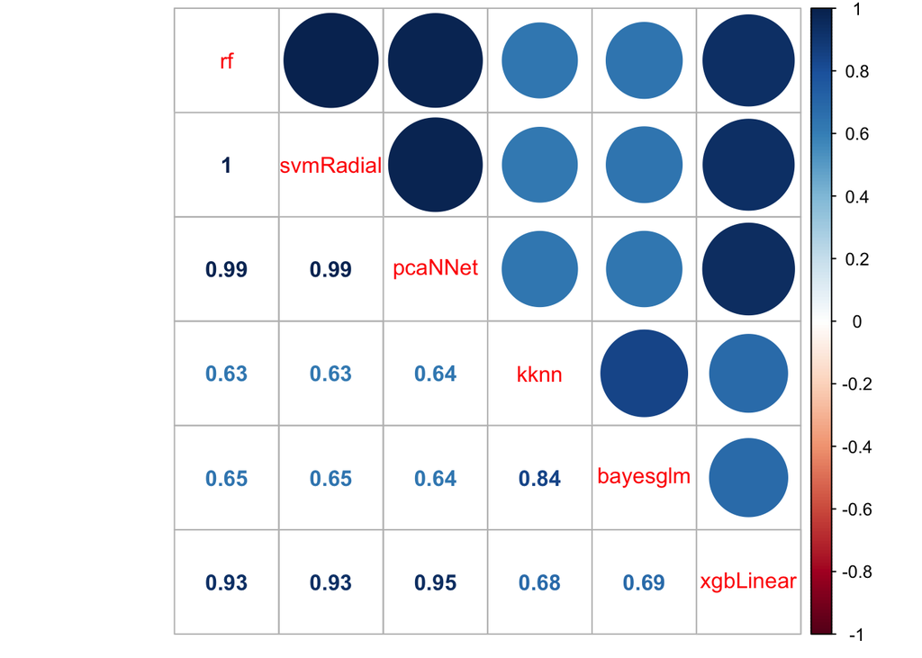

```r
M <- cor(sapply(prediction.train.train,as.numeric))
corrplot.mixed(M)
```

### Ensambling 1: stacking

```r
# firstLayer <- c("kknn","bayesglm","svmRadial","xgbLinear")
firstLayer <- c("kknn","bayesglm")
df.prediction <- prediction.train.train %>% select(firstLayer) %>% mutate(Survived = train.train$Survived)

model.rfSecondLayer <- train(Survived~.,data=df.prediction, method="rf", trControl = ctrl)
temp <- models.train.train
temp$rfSecondLayer <- model.rfSecondLayer
results <- modelResults.list(temp,c("Accuracy","AccuracySD","Kappa","KappaSD"))
```

### Ensambling 2: majority vote

```r
mode <- function(x){
    names(which.max(
        table(x) # frequency table
    ) # column with max value
    ) # names for the max column
}
```

```r
## Ensamble method that uses a majority vote
## x data.frame in input
majorityVote <- function (x){
    as.factor(
        apply(x,1,mode)
    )
}
```

```r
modelTagsMaj <- c("svmRadial", "bayesglm", "kknn")

df.prediction <- prediction.train.train %>% select(modelTagsMaj)
prediction.train.train <- prediction.train.train %>%
    mutate(majVote=majorityVote(df.prediction))
```

## Model validation

The trained models are used to predict the outcome in the test dataset in order to estimate the out of sample error and avoid overfitting:

### Base models prediction

```r
df = train.test

set.seed(5102)

prediction.train.test <- predict.list(models.train.train,df)
```

## Stacked model prediction

```r
df <- prediction.train.test %>% select(firstLayer) %>% mutate(Survived = train.test$Survived)
prediction.train.test$rfSecondLayer <- predict(model.rfSecondLayer,df)
```

## Majority vote prediction

```r
df.prediction <- prediction.train.test %>% select(modelTagsMaj)
prediction.train.test <- prediction.train.test %>%
    mutate(majVote=majorityVote(df.prediction))
```

### Results

```r
df <- train.test

confusionMatrixes.test <- confusionMatrix.list(prediction.train.test,df$Survived)
performance <- as.data.frame(sapply(confusionMatrixes.test, function(cm){
    c(cm$byClass,cm$overall)
})) %>% rownames_to_column(var = "metric") %>% filter(metric %in% c("Accuracy","AccuracyLower","AccuracyUpper","Sensitivity","Specificity","Balanced Accuracy"))

# Results in Train
results
```

```
## # A tibble: 7 x 5
##   Algorithm           Accuracy AccuracySD Kappa KappaSD
##   <chr>                  <dbl>      <dbl> <dbl>   <dbl>
## 1 train_bayesglm         0.792     0.0598 0.552   0.120
## 2 train_kknn             0.749     0.0580 0.478   0.109
## 3 train_pcaNNet          0.837     0.0537 0.636   0.128
## 4 train_rf               0.837     0.0567 0.637   0.128
## 5 train_rfSecondLayer    0.803     0.0625 0.579   0.138
## 6 train_svmRadial        0.839     0.0555 0.643   0.128
## 7 train_xgbLinear        0.835     0.0538 0.634   0.121
```

```r
# Results in Test
performance
```

```
##              metric        rf svmRadial   pcaNNet      kknn  bayesglm
## 1       Sensitivity 0.9197080 0.9124088 0.9270073 0.8394161 0.7956204
## 2       Specificity 0.6470588 0.6588235 0.6470588 0.7411765 0.7529412
## 3 Balanced Accuracy 0.7833834 0.7856161 0.7870331 0.7902963 0.7742808
## 4          Accuracy 0.8153153 0.8153153 0.8198198 0.8018018 0.7792793
## 5     AccuracyLower 0.7579112 0.7579112 0.7628327 0.7432120 0.7189151
## 6     AccuracyUpper 0.8640866 0.8640866 0.8680464 0.8521402 0.8320228
##   xgbLinear rfSecondLayer   majVote
## 1 0.9343066     0.8394161 0.8102190
## 2 0.6117647     0.7411765 0.7647059
## 3 0.7730356     0.7902963 0.7874624
## 4 0.8108108     0.8018018 0.7927928
## 5 0.7530008     0.7432120 0.7334642
## 6 0.8601154     0.8521402 0.8441229
```

The accuracy in the test dataset is not so high: 0.8018018 but int the same time is not so different form the one got in the train dataset: 0.8026989

## Variable importance

```r
varImp(models.train.train$rf,scale = FALSE)
```

```
## rf variable importance
##
##                 Overall
## Sexmale          60.008
## AnySurvivorTRUE  38.623
## Pclass3          15.362
## Fare.grouplow    10.267
## Pclass2           4.108
## Age.bin(10,45]    3.335
## Age.bin(45,99]    2.825
```

```r
varImp(model.rfSecondLayer,scale = FALSE)
```

```
## rf variable importance
##
##                  Overall
## kknnsurvived       99.49
## bayesglmsurvived   24.69
```

# Predict with the test dataset

```r
df = test

set.seed(5102)

prediction.test <- predict.list(models.train.train,df)

df.prediction <- prediction.test %>% select(firstLayer)
prediction.test$rfSecondLayer <- predict(model.rfSecondLayer,df.prediction)

df.prediction <- prediction.test %>% select(modelTagsMaj)
prediction.test <- prediction.test %>%
    mutate(majVote=majorityVote(df.prediction))
```

```r
df = test
prediction.test$final <- as.factor(prediction.test$rfSecondLayer); levels(prediction.test$final) <- origLevels
write.csv(data.frame(PassengerId = df$PassengerId,Survived = prediction.test$final),"solution.csv",row.names = FALSE)
```